# 05b_Figures_Map

J Andres Gannon, Erik Gartzke, and Jon Lindsay, Center for Peace and Security Studies (cPASS)

2019-06-17

This document visualizes the geographic relationship between deterrence and the severity of Russian cyber operations.

Research assistance for this rmd provided by Cole Reynolds.

# Preparation

## Load packages

Pipe operators have trouble loading for individual commands

```r
library(magrittr)
library(ggplot2)
```

## Load data

Load the cleaned and subset versions of each dataset

```r
# Load data
russia_cyber <- readRDS(paste0(here::here(), '/data/grayzone_aggregate_cpass.rds'))
```

## Check data

```r
summary(russia_cyber)
```

```
##     target            year_start    resp_convmil    resp_convmil_gro
##  Length:82          Min.   :1994   Min.   :0.0000   Min.   :0.0000
##  Class :character   1st Qu.:2008   1st Qu.:0.0000   1st Qu.:0.0000
##  Mode  :character   Median :2014   Median :0.0000   Median :0.0000
##                     Mean   :2011   Mean   :0.2683   Mean   :0.2073
##                     3rd Qu.:2016   3rd Qu.:1.0000   3rd Qu.:0.3750
##                     Max.   :2018   Max.   :1.0000   Max.   :1.0000
##
##  resp_convmil_airsea  resp_paramil   resp_cyberdisrup  resp_infoops
##  Min.   :0.0000      Min.   :0.000   Min.   :1        Min.   :0.0000
##  1st Qu.:0.0000      1st Qu.:0.000   1st Qu.:1        1st Qu.:0.0000
##  Median :0.0000      Median :0.000   Median :1        Median :1.0000
##  Mean   :0.2152      Mean   :0.284   Mean   :1        Mean   :0.7027
##  3rd Qu.:0.0000      3rd Qu.:1.000   3rd Qu.:1        3rd Qu.:1.0000
##  Max.   :1.0000      Max.   :1.000   Max.   :1        Max.   :1.0000
##  NA's   :3           NA's   :1       NA's   :9        NA's   :8
##     source             notes                new
##  Length:82          Length:82          Min.   :1
##  Class :character   Class :character   1st Qu.:1
##  Mode  :character   Mode  :character   Median :1
##                                        Mean   :1
##                                        3rd Qu.:1
##                                        Max.   :1
##                                        NA's   :72
##                                     incident       dcid         rei
##  Presidential elections                 : 8   Min.   :1    Min.   :1
##  General elections                      : 4   1st Qu.:1    1st Qu.:1
##  CyberBerkut NATO Websites              : 3   Median :1    Median :1
##  Duke Series                            : 3   Mean   :1    Mean   :1
##  Energetic Bear/Dragonfly/Crouching Yeti: 3   3rd Qu.:1    3rd Qu.:1
##  (Other)                                :51   Max.   :1    Max.   :1
##  NA's                                   :10   NA's   :40   NA's   :51
##  dcid_severity    rei_infoops     rei_cyberdisrup   rei_matsupp
##  Min.   :1.000   Min.   :0.0000   Min.   :0.0000   Min.   :0.0000
##  1st Qu.:2.000   1st Qu.:0.0000   1st Qu.:0.0000   1st Qu.:0.0000
##  Median :2.500   Median :1.0000   Median :1.0000   Median :0.0000
##  Mean   :2.762   Mean   :0.5161   Mean   :0.5161   Mean   :0.4194
##  3rd Qu.:4.000   3rd Qu.:1.0000   3rd Qu.:1.0000   3rd Qu.:1.0000
##  Max.   :4.000   Max.   :1.0000   Max.   :1.0000   Max.   :1.0000
##  NA's   :40      NA's   :51       NA's   :51       NA's   :51
```

# Prior data maps

Map the data using prior variable codings from other datasets

## DCID

Map of the DCID cases showing variation in severity

```r
dcid <- readRDS(file = paste0(here::here(),"/data/grayzone_dcid.rds"))

country <- unique(dcid$Target)
average_severity <- NULL
for( i in 1:length(country)){
  average_severity[i] <- round(mean(dcid[dcid$Target == country[i], "Incident severity"]), 2)
}

dcid <- as.data.frame(cbind(country, average_severity), stringsAsFactors = F)
dcid$average_severity <- as.numeric(dcid$average_severity)

map <- rworldmap::joinCountryData2Map(dcid,
                                      nameJoinColumn="country",
                                      joinCode="NAME" )
```

```
## 8 codes from your data successfully matched countries in the map
## 0 codes from your data failed to match with a country code in the map
## 235 codes from the map weren't represented in your data
```

```r
rworldmap::mapDevice()

mapParams <- rworldmap::mapCountryData(map,
                                       nameColumnToPlot='average_severity',
                                       catMethod = c(2, 2.3, 2.6, 2.9, 3.2, 3.5),
                                       mapTitle = "\nRussian cyber attack severity (2005-2016) - Valeriano and Maness data",
                                       addLegend = FALSE,
                                       xlim = c(-167, 50),
                                       ylim = c(30,50)
                                      )
```

[output not shown]

## REI

```r
rei <- readRDS(file = paste0(here::here(),"/data/grayzone_rei.rds"))

rei[rei$Target == "Ukraine ", "Target"] <- "Ukraine"

country <- unique(rei$Target)
average_severity <- NULL
for( i in 1:length(country)){
  average_severity[i] <- round(mean(rei[rei$Target == country[i], "Favorable outcome"]), 2)
}

rei <- as.data.frame(cbind(country, average_severity), stringsAsFactors = F)
rei$average_severity <- as.numeric(rei$average_severity)

map <- rworldmap::joinCountryData2Map(rei,
                                      nameJoinColumn="country",
                                      joinCode="NAME" )
```

```
## 16 codes from your data successfully matched countries in the map
## 0 codes from your data failed to match with a country code in the map
## 227 codes from the map weren't represented in your data
```

```r
rworldmap::mapDevice()

mapParams <- rworldmap::mapCountryData(map,
                                       nameColumnToPlot = 'average_severity',
                                       catMethod = c(0, 0.4, 0.8, 1.2, 1.6, 2),
                                       mapTitle = "\nRussian cyber attack severity (1994-2017) - Way and Casey data",
                                       #colourPalette = c("lightgoldenrod", "yellow", "orange", "red"),
                                       addLegend = FALSE,
                                       xlim = c(-167, 50),
                                       ylim = c(30,50)
                                      )
```

[output not shown]

## Combined

There should only be one case that is coded in both DCID and REI. For all the rest, scale their scores so we get a single score for each case in either dataset and we can compare across datasets. We know this is a rough coding since one is coding severity of the cyber attack and the other is coding the type of attack, but we’ll start here.

# Current data maps

```r
rei_dcid <- readRDS(paste0(here::here(), "/data/grayzone_aggregate_cpass.rds"))

rei_dcid[rei_dcid$target == "Chechnya", "target"] <- "Russia"

rei_dcid[is.na(rei_dcid[,4]), 4] <- 0
rei_dcid[is.na(rei_dcid[,5]), 5] <- 0
rei_dcid[is.na(rei_dcid[,6]), 6] <- 0
rei_dcid[is.na(rei_dcid[,7]), 7] <- 0
rei_dcid[is.na(rei_dcid[,8]), 8] <- 0

rei_dcid$resp_convmil_gro <- rei_dcid$resp_convmil_gro * 5
rei_dcid$resp_convmil_airsea <- rei_dcid$resp_convmil_airsea * 4
rei_dcid$resp_paramil <- rei_dcid$resp_paramil * 3
rei_dcid$rei_cyberdisrup <- rei_dcid$rei_cyberdisrup * 2

for( i in 1:nrow(rei_dcid)){
  rei_dcid$intensity[i] <- max(rei_dcid$resp_convmil_gro[i], rei_dcid$resp_convmil_airsea[i], rei_dcid$resp_paramil[i], rei_dcid$resp_cyberdisrup[i], rei_dcid$resp_infoops[i])
}

country <- unique(rei_dcid$target)
average_severity <- NULL
for( i in 1:length(country)){
  average_severity[i] <- max(rei_dcid[rei_dcid$target == country[i], "intensity"])
  #average_severity[i] <- round(mean(dcid[dcid$Target == country[i], "severity_comparable"]), 2)
}

rei_dcid <- as.data.frame(cbind(country, average_severity), stringsAsFactors = F)
rei_dcid$average_severity <- as.numeric(rei_dcid$average_severity)
rei_dcid <- rbind(rei_dcid, c("Thailand", 2))

rei_dcid[rei_dcid$average_severity == 1, "average_severity"] <- "1 Info Ops"
rei_dcid[rei_dcid$average_severity == 2, "average_severity"] <- "2 Cyber Disruption"
rei_dcid[rei_dcid$average_severity == 3, "average_severity"] <- "3 Paramilitary"
rei_dcid[rei_dcid$average_severity == 4, "average_severity"] <- "4 Conventional Military (air/sea)"
rei_dcid[rei_dcid$average_severity == 5, "average_severity"] <- "5 Conventional Military (ground)"

map <- rworldmap::joinCountryData2Map(rei_dcid,
                                      nameJoinColumn="country",
                                      joinCode="NAME" )
```

```
## 30 codes from your data successfully matched countries in the map
## 0 codes from your data failed to match with a country code in the map
## 217 codes from the map weren't represented in your data
```

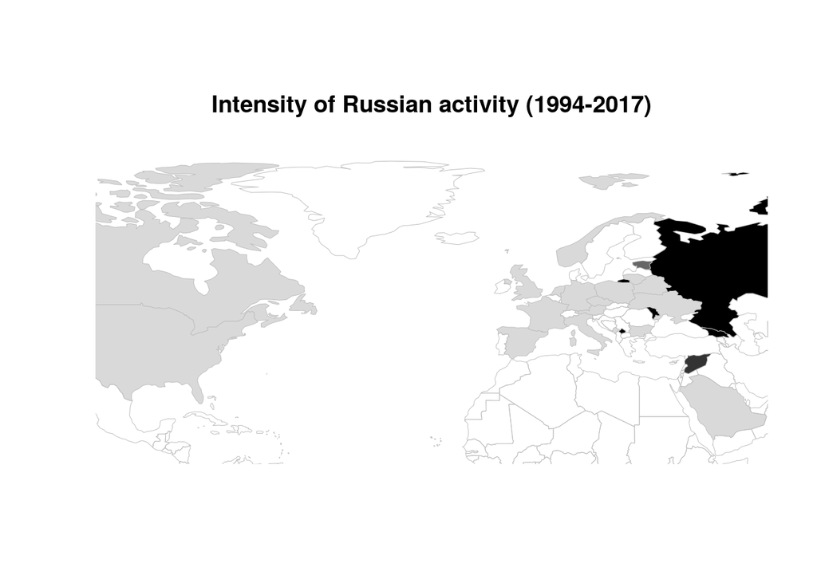

```r
mapParams <- rworldmap::mapCountryData(map,
                                       nameColumnToPlot='average_severity',
                                       catMethod = "categorical",
                                       #catMethod = c(0, 0.4, 0.8, 1.2, 1.6, 2),
                                       mapTitle = "\n\n\n\nIntensity of Russian activity (1994-2017)",
                                       addLegend = FALSE,
                                       xlim = c(-100,50), #c(-157, 50),
                                       ylim = c(40,70), #c(30,50),
                                       #colourPalette = RColorBrewer::brewer.pal(5, "Greys")
                                       colourPalette = c("grey85", "grey60", "grey40", "grey20", "grey0")
)
```

```r
mapParams$legendText <- c("Info Ops", "Cyber Disruption", "Paramilitary", "Conventional Military (air/sea)", "Conventional Military (ground)")
```